# Ejemplo reglas de asociación

En este ejercicio se dispone del registro de todas las compras que se han realizado en un supermercado. El objetivo del análisis es identificar productos que tiendan a comprarse de forma conjunta para así poder situarlos en posiciones cercanas dentro de la tienda y maximizar la probabilidad de que los clientes compren.

Para este ejemplo se emplea el set de datos Groceries del paquete arules, que contiene un registro de las ventas realizadas por un supermercado durante 30 días. En total se dispone de 9835 transacciones formadas por combinaciones de 169 productos. La variable Groceries almacena la información en un formato propio de este paquete (descrito más adelante). Para representar mejor lo que suele ocurrir en la práctica, se ha reestructurado la información en formato de tabla.

Primero instalaremos el paquete arules donde se encuentra el algoritmo apriori y el dataset que vamos a utilizar.

```r
install.packages("tidyverse")
install.packages("arules")
```

Cargamos las librerías.

```r
library(arules)
library(ggplot2)
```

# Lectura del fichero

Con la función read.transactions() se pueden leer directamente los datos de archivos tipo texto y almacenarlos en un objeto de tipo transactions, que es la estructura de almacenamiento que emplea arules. Esta función tiene los siguientes argumentos:

- file: nombre del archivo que se quiere leer.
- format: estructura en la que se encuentran almacenados los datos, “basket” si cada línea del archivo es una transacción completa, o “single” si cada línea representa un item.
- sep: tipo de separación de los campos.
- header: valor booleano que indica si el nombre de las variables se encuentra en la primera fila.
- cols: si el formato es de tipo “basket”, un entero que indica la columna que contiene el identificador de las transacciones. Para el formato “single”, es un vector con los nombres (o posiciones) de las dos columnas que identifican las transacciones y los items, respectivamente.
- rm.duplicates: valor lógico indicando si se eliminan los items duplicados en una misma transacción. Por lo general, es conveniente eliminarlos, el interés suele estar en qué items ocurren de forma conjunta, no en qué cantidad.
- quote: carácter que se utiliza como comillas.
- skip: número de líneas que hay que saltar desde el comienzo del fichero.

Los objetos transactions, se almacenan internamente como un tipo de matriz binaria. Se trata de una matriz de valores 0/1, con una fila por cada transacción, en este caso cada compra, y una columna por cada posible item, en este caso productos. La posición de la matriz (i,j) tiene el valor 1 si la transacción i contiene el item j.

```r
groceries <- read.transactions(file = "datos_groceries.csv",
                                   format = "single",
                                   sep = ",",
                                   header=TRUE,
                                   cols = c("id_compra", "item"),
                                   rm.duplicates = TRUE)

summary(groceries)
```

```
transactions as itemMatrix in sparse format with
 9835 rows (elements/itemsets/transactions) and
 169 columns (items) and a density of 0.02609146

most frequent items:
      whole milk other vegetables       rolls/buns             soda           yogurt
            2513             1903             1809             1715             1372
         (Other)
           34055

element (itemset/transaction) length distribution:
sizes
   1    2    3    4    5    6    7    8    9   10   11   12   13   14   15   16   17   18   19   20
2159 1643 1299 1005  855  645  545  438  350  246  182  117   78   77   55   46   29   14   14    9
  21   22   23   24   26   27   28   29   32
  11    4    6    1    1    1    1    3    1

   Min. 1st Qu.  Median    Mean 3rd Qu.    Max.
  1.000   2.000   3.000   4.409   6.000  32.000

includes extended item information - examples:
```

|  | labels |
| --- | --- |
| 1 | abrasive cleaner |
| 2 | artif. sweetener |
| 3 | baby cosmetics |

```
includes extended transaction information - examples:
```

|  | transactionID |
| --- | --- |
| 1 | 1 |
| 2 | 10 |
| 3 | 100 |

Cada línea del archivo contiene la información de un item y el identificador de la transacción (compra) a la que pertenece. Esta es la estructura en la que comúnmente se almacenan los datos dentro de una base de datos y que, en el ámbito de las transacciones, recibe el nombre de tabla larga o single. Otra forma en la que se pueden encontrar los datos de transacciones es en formato matriz o tabla ancha, en el que cada fila contiene todos los items que forman parte de una misma transacción, este formato recibe el nombre de cesta o basket.

El concepto de transacción hace referencia al conjunto de items o eventos que ocurren de forma conjunta. Para este caso de estudio, compras de supermercado, cada transacción está formada por todos los productos que se compran a la vez, es decir, el vínculo de unión no es el cliente sino cada una de las “cestas de la compra”. Por ejemplo, la transacción con id_compra == 14 está formada por 3 items.

Visualizar las primeras 5 transacciones con la función inspect.

```r
inspect(groceries[1:5])
```

```
    items                   transactionID
[1] {citrus fruit,
     margarine,
     ready soups,
     semi-finished bread}            1
[2] {cereals,
     whole milk}                     10
[3] {citrus fruit,
     tropical fruit}                 100
[4] {artif. sweetener,
     chocolate marshmallow,
     flour,
     margarine,
     organic products,
     other vegetables,
     pork,
     semi-finished bread,
     tropical fruit,
     yogurt}                         1000
[5] {domestic eggs,
     hygiene articles,
     onions,
     soda}                           1001
```

```r
#Convertir a dataframe
df_groceries=as(groceries, Class="data.frame")


ggplot(df_groceries, aes(x=tamanyos))+
  geom_histogram()+
  xlab("Distribucion del tamaño de las transacciones")+
  ylab("Tamaño")+
  theme_bw()
```

[output not shown]

[output not shown]

El siguiente análisis básico consiste en identificar cuáles son los items más frecuentes (los que tienen mayor soporte) dentro del conjunto de todas las transacciones. Con la función *itemFrequency()* se puede extraer esta información de un objeto tipo transactions. El nombre de esta función puede causar confusión. Por “frecuencia” se hace referencia al soporte de cada item, que es la fracción de transacciones que contienen dicho item respecto al total de todas las transacciones. Esto es distinto a la frecuencia de un item respecto al total de items, de ahí que la suma de todos los soportes no sea 1.

Examinar la frecuencia de los items con la función itemFrequency.

```r
itemFrequency(groceries[, 1:3])
```

```
abrasive cleaner artif. sweetener   baby cosmetics
    0.0035587189     0.0032536858     0.0006100661
```

```r
frecuenciaItems=itemFrequency(x=groceries, type="relative")
#frecuenciaItems
frecuenciaItems2=sort(frecuenciaItems, decreasing=TRUE)
head(frecuenciaItems2)
```

```
      whole milk other vegetables       rolls/buns             soda           yogurt
       0.2555160        0.1934926        0.1839349        0.1743772        0.1395018
   bottled water
       0.1105236
```

Si se indica el argumento type = “absolute”, la función itemFrequency() devuelve el número de transacciones en las que aparece cada item.

```r
frecuenciaItems=itemFrequency(x=groceries, type="absolute")
#frecuenciaItems
frecuenciaItems2=sort(frecuenciaItems, decreasing=TRUE)
head(frecuenciaItems2)
```

```
      whole milk other vegetables       rolls/buns             soda           yogurt
            2513             1903             1809             1715             1372
   bottled water
            1087
```

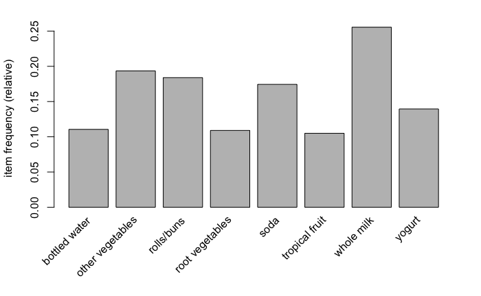

```r
# plot the frequency of items
itemFrequencyPlot(groceries, support = 0.1)
```

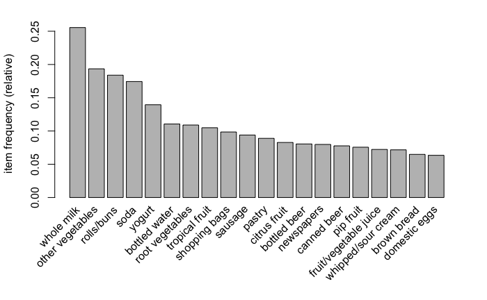

```r
itemFrequencyPlot(groceries, topN = 20)
```

Es muy importante estudiar cómo se distribuye el soporte de los items individuales en un conjunto de transacciones antes identificar itemsets frecuentes o crear reglas de asociación, ya que, dependiendo del caso, tendrá sentido emplear un límite de soporte u otro. Por lo general, cuando el número de posibles items es muy grande (varios miles) prácticamente todos los artículos son raros, por lo que los soportes son muy bajos.

#Algoritmo apriori

Con la función apriori() se puede aplicar el algoritmo Apriori a un objeto de tipo transactions y extraer tanto itemsets frecuentes como reglas de asociación que superen un determinado soporte y confianza. Los argumentos de esta función son:

- data: un objeto del tipo transactions o un objeto que pueda ser convertido a tipo transactions, por ejemplo un dataframe o una matriz binaria.
- parameter: lista en la que se indican los parámetros del algoritmo.
- support: soporte mínimo que debe tener un itemset para ser considerado frecuente. Por defecto es 0.1.
- minlen: número mínimo de items que debe tener un itemset para ser incluido en los resultados. Por defecto 1.
- maxlen: número máximo de items que puede tener un itemset para ser incluido en los resultados. Por defecto 10.
- target: tipo de resultados que debe de generar el algoritmo, pueden ser “frequent itemsets”, “maximally frequent itemsets”, “closed frequent itemsets”, “rules” o “hyperedgesets”.
- confidence: confianza mínima que debe de tener una regla para ser incluida en los resultados. Por defecto 0.8.
- maxtime: tiempo máximo que puede estar el algoritmo buscando subsets. Por defecto 5 segundos.
- appearance: lista que permite definir patrones para restringir el espacio de búsqueda, por ejemplo, especificando qué items pueden o no pueden aparecer.
- control: lista que permite modificar aspectos internos de algoritmo como la ordenación de los itemsets, si se construye un árbol con las transacciones, aspectos relacionados con el uso de memoria, etc.

**IMPORTANTE** Vamos a calcular los itemsets, incluidos, incluidos los formados por un único item, que hayan sido comprados al menos 30 veces. Para definir el soporte se usará este valor dividido entre el total de transacciones.

```r
soporte <- 30 / dim(groceries)[1]
print(soporte)
```

```
[1] 0.00305033
```

```r
a<-dim(groceries)[1]
print(a)
```

```
[1] 9835
```

Usamos la función a priori:

```r
itemsets <- apriori(data = groceries,
                    parameter = list(support = soporte,
                                     minlen = 1,
                                     maxlen = 20,
                                     target = "frequent itemset"))
```

```
Apriori

Parameter specification:
```

|  | confidence | minval | smax | arem | aval | originalSupport | maxtime | support | minlen | maxlen | target | ext |
| --- | --- | --- | --- | --- | --- | --- | --- | --- | --- | --- | --- | --- |
|  | NA | 0.1 | 1 | none | FALSE | TRUE | 5 | 0.00305033 | 1 | 20 | frequent itemsets | FALSE |

```
Algorithmic control:
```

|  | filter | tree | heap | memopt | load | sort | verbose |
| --- | --- | --- | --- | --- | --- | --- | --- |
|  | 0.1 | TRUE | TRUE | FALSE | TRUE | 2 | TRUE |

```
Absolute minimum support count: 30

set item appearances ...[0 item(s)] done [0.00s].
set transactions ...[169 item(s), 9835 transaction(s)] done [0.01s].
sorting and recoding items ... [136 item(s)] done [0.00s].
creating transaction tree ... done [0.00s].
checking subsets of size 1 2 3 4 5 done [0.01s].
writing ... [2226 set(s)] done [0.00s].
creating S4 object  ... done [0.01s].
```

```r
summary(itemsets)
```

```
set of 2226 itemsets

most frequent items:
      whole milk other vegetables           yogurt  root vegetables       rolls/buns
             556              468              316              251              241
         (Other)
            3536

element (itemset/transaction) length distribution:sizes
   1    2    3    4    5
 136 1140  850   98    2

   Min. 1st Qu.  Median    Mean 3rd Qu.    Max.
  1.000   2.000   2.000   2.412   3.000   5.000

summary of quality measures:
    support             count
 Min.   :0.003050   Min.   :  30.00
 1st Qu.:0.003660   1st Qu.:  36.00
 Median :0.004779   Median :  47.00
 Mean   :0.007879   Mean   :  77.49
 3rd Qu.:0.007219   3rd Qu.:  71.00
 Max.   :0.255516   Max.   :2513.00

includes transaction ID lists: FALSE

mining info:
```

|  | data | ntransactions | support | confidence |
| --- | --- | --- | --- | --- |
|  | groceries | 9835 | 0.00305033 | 1 |

```r
# Se muestran los top 20 itemsets de mayor a menor soporte
top_20_itemsets <- sort(itemsets, by = "support", decreasing = TRUE)[1:20]
inspect(top_20_itemsets)
```

|  | items | support | count |
| --- | --- | --- | --- |
| [1] | {whole milk} | 0.25551601 | 2513 |
| [2] | {other vegetables} | 0.19349263 | 1903 |
| [3] | {rolls/buns} | 0.18393493 | 1809 |
| [4] | {soda} | 0.17437722 | 1715 |
| [5] | {yogurt} | 0.13950178 | 1372 |
| [6] | {bottled water} | 0.11052364 | 1087 |
| [7] | {root vegetables} | 0.10899847 | 1072 |
| [8] | {tropical fruit} | 0.10493137 | 1032 |
| [9] | {shopping bags} | 0.09852567 | 969 |
| [10] | {sausage} | 0.09395018 | 924 |

[output cut: 10 more lines]

La representación gráfica de estos resultados en forma de histograma. Al igual que en el caso anterior, para poder usar la función ggplot hay que convertir la variable top_20_itemsets a una variable de tipo dataframe con la función as().

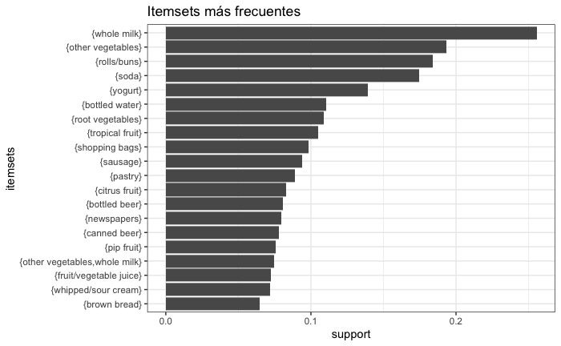

```r
#Convertir a dataframe
df_top20=as(top_20_itemsets, Class="data.frame")


ggplot(df_top20, aes(x = reorder(items, support), y = support)) +
  geom_col() +
  coord_flip() +
  labs(title = "Itemsets más frecuentes", x = "itemsets") +
  theme_bw()
```

Si se quieren excluir del análisis los itemsets formados únicamente por un solo item, se puede aplicar de nuevo la función apriori() especificando minlen = 2.

```r
itemsets <- apriori(data = groceries,
                    parameter = list(support = soporte,
                                     minlen = 2,
                                     maxlen = 20,
                                     target = "frequent itemset"))
```

```
Apriori

Parameter specification:
```

|  | confidence | minval | smax | arem | aval | originalSupport | maxtime | support | minlen | maxlen | target | ext |
| --- | --- | --- | --- | --- | --- | --- | --- | --- | --- | --- | --- | --- |
|  | NA | 0.1 | 1 | none | FALSE | TRUE | 5 | 0.00305033 | 2 | 20 | frequent itemsets | FALSE |

```
Algorithmic control:
```

|  | filter | tree | heap | memopt | load | sort | verbose |
| --- | --- | --- | --- | --- | --- | --- | --- |
|  | 0.1 | TRUE | TRUE | FALSE | TRUE | 2 | TRUE |

```
Absolute minimum support count: 30

set item appearances ...[0 item(s)] done [0.00s].
set transactions ...[169 item(s), 9835 transaction(s)] done [0.01s].
sorting and recoding items ... [136 item(s)] done [0.00s].
creating transaction tree ... done [0.00s].
checking subsets of size 1 2 3 4 5 done [0.01s].
writing ... [2090 set(s)] done [0.00s].
creating S4 object  ... done [0.01s].
```

```r
summary(itemsets)
```

```
set of 2090 itemsets

most frequent items:
      whole milk other vegetables           yogurt  root vegetables       rolls/buns
             555              467              315              250              240
         (Other)
            3405

element (itemset/transaction) length distribution:sizes
   2    3    4    5
1140  850   98    2

   Min. 1st Qu.  Median    Mean 3rd Qu.    Max.
  2.000   2.000   2.000   2.503   3.000   5.000

summary of quality measures:
    support             count
 Min.   :0.003050   Min.   : 30.00
 1st Qu.:0.003559   1st Qu.: 35.00
 Median :0.004575   Median : 45.00
 Mean   :0.006305   Mean   : 62.01
 3rd Qu.:0.006711   3rd Qu.: 66.00
 Max.   :0.074835   Max.   :736.00

includes transaction ID lists: FALSE

mining info:
```

|  | data | ntransactions | support | confidence |
| --- | --- | --- | --- | --- |
|  | groceries | 9835 | 0.00305033 | 1 |

Mostrar los 20 itemsets más frecuentes formados por más de un item con la función inspect().

```r
# Se muestran los 20 itemsets más frecuentes formados por más de un item.
inspect(sort(itemsets[size(itemsets) > 1], decreasing = TRUE)[1:20])
```

|  | items | support | count |
| --- | --- | --- | --- |
| [1] | {other vegetables,whole milk} | 0.07483477 | 736 |
| [2] | {rolls/buns,whole milk} | 0.05663447 | 557 |
| [3] | {whole milk,yogurt} | 0.05602440 | 551 |
| [4] | {root vegetables,whole milk} | 0.04890696 | 481 |
| [5] | {other vegetables,root vegetables} | 0.04738180 | 466 |
| [6] | {other vegetables,yogurt} | 0.04341637 | 427 |
| [7] | {other vegetables,rolls/buns} | 0.04260295 | 419 |
| [8] | {tropical fruit,whole milk} | 0.04229792 | 416 |
| [9] | {soda,whole milk} | 0.04006101 | 394 |
| [10] | {rolls/buns,soda} | 0.03833249 | 377 |

[output cut: 10 more lines]

# Filtrado de itemsets

Una vez que los itemsets frecuentes han sido identificados mediante el algoritmo Apripori, pueden ser filtrados con la función subset(). Esta función recibe dos argumentos: un objeto itemset o rules y una condición lógica que tienen que cumplir las reglas/itemsets para ser seleccionados. La siguiente tabla muestra los operadores permitidos:

| Operador | Significado |
| --- | --- |
| & | AND |
| %in% | contiene cualquier de los siguientes elementos |
| %ain% | contiene todos de los siguientes elementos |
| %pin% | contiene parcialmente los siguientes elementos |

Como esta función tiene el mismo nombre que una función del paquete básico de R, para evitar errores, es conveniente especificar el paquete donde se encuentra.

Se procede a identificar aquellos itemsets frecuentes que contienen el item newspapers y se muestran los 10 primeros.

```r
itemsets_filtrado <- arules::subset(itemsets,
                                    subset = items %in% "newspapers")
itemsets_filtrado
```

```
set of 79 itemsets
```

```r
# Se muestran 10 de ellos
inspect(itemsets_filtrado[1:10])
```

|  | items | support | count |
| --- | --- | --- | --- |
| [1] | {meat,newspapers} | 0.003050330 | 30 |
| [2] | {newspapers,sliced cheese} | 0.003152008 | 31 |
| [3] | {newspapers,UHT-milk} | 0.004270463 | 42 |
| [4] | {newspapers,oil} | 0.003152008 | 31 |
| [5] | {newspapers,onions} | 0.003152008 | 31 |
| [6] | {hygiene articles,newspapers} | 0.003050330 | 30 |
| [7] | {newspapers,sugar} | 0.003152008 | 31 |
| [8] | {newspapers,waffles} | 0.004168785 | 41 |
| [9] | {long life bakery product,newspapers} | 0.003457041 | 34 |
| [10] | {dessert,newspapers} | 0.003558719 | 35 |

¿Y si quisiesemos mostrar aquellos itemsets que contienen newspapers y whole milk?

```r
itemsets_filtrado <- arules::subset(itemsets,
                                    subset = items %ain% c("newspapers", "whole milk"))
itemsets_filtrado
```

```
set of 16 itemsets
```

```r
inspect(itemsets_filtrado[1:10])
```

|  | items | support | count |
| --- | --- | --- | --- |
| [1] | {newspapers,whole milk} | 0.027351296 | 269 |
| [2] | {chocolate,newspapers,whole milk} | 0.003152008 | 31 |
| [3] | {brown bread,newspapers,whole milk} | 0.004067107 | 40 |
| [4] | {margarine,newspapers,whole milk} | 0.003152008 | 31 |
| [5] | {butter,newspapers,whole milk} | 0.003152008 | 31 |
| [6] | {newspapers,pastry,whole milk} | 0.003863752 | 38 |
| [7] | {citrus fruit,newspapers,whole milk} | 0.003355363 | 33 |
| [8] | {newspapers,sausage,whole milk} | 0.003050330 | 30 |
| [9] | {bottled water,newspapers,whole milk} | 0.004067107 | 40 |
| [10] | {newspapers,tropical fruit,whole milk} | 0.005083884 | 50 |

```r
NA
```

# Reglas de asociación

Para crear las reglas de asociación se sigue el mismo proceso que para obtener itemsets frecuentes pero, además de especificar un soporte mínimo, se tiene que establecer una confianza mínima para que una regla se incluya en los resultados. En este caso, se emplea una confianza mínima del 70%.

```r
soporte <- 30 / dim(groceries)[1]
reglas <- apriori(data = groceries,
                  parameter = list(support = soporte,
                                   confidence = 0.70,
                                   # Se especifica que se creen reglas
                                   target = "rules"))
```

```
Apriori

Parameter specification:
```

|  | confidence | minval | smax | arem | aval | originalSupport | maxtime | support | minlen | maxlen | target | ext |
| --- | --- | --- | --- | --- | --- | --- | --- | --- | --- | --- | --- | --- |
|  | 0.7 | 0.1 | 1 | none | FALSE | TRUE | 5 | 0.00305033 | 1 | 10 | rules | FALSE |

```
Algorithmic control:
```

|  | filter | tree | heap | memopt | load | sort | verbose |
| --- | --- | --- | --- | --- | --- | --- | --- |
|  | 0.1 | TRUE | TRUE | FALSE | TRUE | 2 | TRUE |

```
Absolute minimum support count: 30

set item appearances ...[0 item(s)] done [0.00s].
set transactions ...[169 item(s), 9835 transaction(s)] done [0.01s].
sorting and recoding items ... [136 item(s)] done [0.00s].
creating transaction tree ... done [0.00s].
checking subsets of size 1 2 3 4 5 done [0.01s].
writing ... [19 rule(s)] done [0.00s].
creating S4 object  ... done [0.01s].
```

```r
summary(reglas)
```

```
set of 19 rules

rule length distribution (lhs + rhs):sizes
3 4 5
7 9 3

   Min. 1st Qu.  Median    Mean 3rd Qu.    Max.
  3.000   3.000   4.000   3.789   4.000   5.000

summary of quality measures:
    support           confidence          lift           count
 Min.   :0.003050   Min.   :0.7000   Min.   :2.740   Min.   :30.00
 1st Qu.:0.003203   1st Qu.:0.7047   1st Qu.:2.758   1st Qu.:31.50
 Median :0.003559   Median :0.7164   Median :2.804   Median :35.00
 Mean   :0.003767   Mean   :0.7373   Mean   :3.044   Mean   :37.05
 3rd Qu.:0.004169   3rd Qu.:0.7500   3rd Qu.:2.984   3rd Qu.:41.00
 Max.   :0.005694   Max.   :0.8857   Max.   :4.578   Max.   :56.00

mining info:
```

|  | data | ntransactions | support | confidence |
| --- | --- | --- | --- | --- |
|  | groceries | 9835 | 0.00305033 | 0.7 |

Para poder visualizar las reglas utilizaremos la función inspect().

La segunda regla se puede interpretar como: si un cliente compra mantequilla, vegetales y yogurt también comprará leche con un support de 0,003 y una confianza del 79%,por lo tanto esta transaccion será correcta en el 79% de compras que involucren mantequilla, vegetales y yogurt.

El indicador lift expresa cuál es la proporción del soporte observado de un conjunto de productos respecto del soporte teórico de ese conjunto dado el supuesto de independencia. * Un valor de lift = 1 indica que ese conjunto aparece una cantidad de veces acorde a lo esperado bajo condiciones de independencia. * Un valor de lift > 1 indica que ese conjunto aparece una cantidad de veces superior a lo esperado bajo condiciones de independencia (por lo que se puede intuir que existe una relación que hace que los productos se encuentren en el conjunto más veces de lo normal). * Un valor de lift < 1 indica que ese conjunto aparece una cantidad de veces inferior a lo esperado bajo condiciones de independencia (por lo que se puede intuir que existe una relación que hace que los productos no estén formando parte del mismo conjunto más veces de lo normal) (Wikipedia).

```r
inspect(sort(x = reglas, decreasing = TRUE, by = "confidence"))
```

```
     lhs                     rhs                    support confidence     lift count
[1]  {citrus fruit,
      root vegetables,
      tropical fruit,
      whole milk}         => {other vegetables} 0.003152008  0.8857143 4.577509    31
[2]  {butter,
      root vegetables,
      yogurt}             => {whole milk}       0.003050330  0.7894737 3.089723    30
[3]  {citrus fruit,
      root vegetables,
      tropical fruit}     => {other vegetables} 0.004473818  0.7857143 4.060694    44
[4]  {brown bread,
      other vegetables,
      root vegetables}    => {whole milk}       0.003152008  0.7750000 3.033078    31
[5]  {butter,
      onions}             => {whole milk}       0.003050330  0.7500000 2.935237    30
[6]  {curd,
      tropical fruit,
      yogurt}             => {whole milk}       0.003965430  0.7500000 2.935237    39
[7]  {curd,
      domestic eggs}      => {whole milk}       0.004778851  0.7343750 2.874086    47
[8]  {butter,
      tropical fruit,
      yogurt}             => {whole milk}       0.003355363  0.7333333 2.870009    33
[9]  {root vegetables,
      tropical fruit,
      whipped/sour cream} => {other vegetables} 0.003355363  0.7333333 3.789981    33
[10] {butter,
      curd}               => {whole milk}       0.004880529  0.7164179 2.803808    48
[11] {domestic eggs,
      sugar}              => {whole milk}       0.003558719  0.7142857 2.795464    35
[12] {other vegetables,
      root vegetables,
      tropical fruit,
      yogurt}             => {whole milk}       0.003558719  0.7142857 2.795464    35
[13] {baking powder,
      yogurt}             => {whole milk}       0.003253686  0.7111111 2.783039    32
[14] {tropical fruit,
      whipped/sour cream,
      yogurt}             => {whole milk}       0.004372140  0.7049180 2.758802    43
[15] {citrus fruit,
      other vegetables,
      root vegetables,
      tropical fruit}     => {whole milk}       0.003152008  0.7045455 2.757344    31
[16] {butter,
      pork}               => {whole milk}       0.003863752  0.7037037 2.754049    38
[17] {butter,
      coffee}             => {whole milk}       0.003355363  0.7021277 2.747881    33
[18] {domestic eggs,
      other vegetables,
      whipped/sour cream} => {whole milk}       0.003558719  0.7000000 2.739554    35
[19] {root vegetables,
      tropical fruit,
      yogurt}             => {whole milk}       0.005693950  0.7000000 2.739554    56
```

## Filtrado de reglas

Cuando se crean reglas de asociación, pueden ser interesantes únicamente aquellas que contienen un determinado conjunto de items en el antecedente o en el consecuente. Con arules existen varias formas de seleccionar solo determinadas reglas.

Es posible restringir los items que aparecen en el lado izquierdo y/o derecho de la reglas a la hora de crearlas, por ejemplo, supóngase que solo son de interés reglas que muestren productos que se vendan junto con other vegetables. Esto significa que el item other vegetables, debe aparecer en el lado derecho (rhs).

Esto mismo puede hacerse con el lado izquierdo (lhs) o en ambos (both).

```r
soporte <- 30 / dim(groceries)[1]
reglas_vegetables <- apriori(data = groceries,
                             parameter = list(support = soporte,
                                              confidence = 0.70,
                                              # Se especifica que se creen reglas
                                              target = "rules"),
                             appearance = list(rhs = "other vegetables"))
```

```
Apriori

Parameter specification:
```

|  | confidence | minval | smax | arem | aval | originalSupport | maxtime | support | minlen | maxlen | target | ext |
| --- | --- | --- | --- | --- | --- | --- | --- | --- | --- | --- | --- | --- |
|  | 0.7 | 0.1 | 1 | none | FALSE | TRUE | 5 | 0.00305033 | 1 | 10 | rules | FALSE |

```
Algorithmic control:
```

|  | filter | tree | heap | memopt | load | sort | verbose |
| --- | --- | --- | --- | --- | --- | --- | --- |
|  | 0.1 | TRUE | TRUE | FALSE | TRUE | 2 | TRUE |

```
Absolute minimum support count: 30

set item appearances ...[1 item(s)] done [0.00s].
set transactions ...[169 item(s), 9835 transaction(s)] done [0.01s].
sorting and recoding items ... [136 item(s)] done [0.00s].
creating transaction tree ... done [0.01s].
checking subsets of size 1 2 3 4 5 done [0.01s].
writing ... [3 rule(s)] done [0.00s].
creating S4 object  ... done [0.00s].
```

```r
summary(reglas_vegetables)
```

```
set of 3 rules

rule length distribution (lhs + rhs):sizes
4 5
2 1

   Min. 1st Qu.  Median    Mean 3rd Qu.    Max.
  4.000   4.000   4.000   4.333   4.500   5.000

summary of quality measures:
    support           confidence          lift           count
 Min.   :0.003152   Min.   :0.7333   Min.   :3.790   Min.   :31.0
 1st Qu.:0.003254   1st Qu.:0.7595   1st Qu.:3.925   1st Qu.:32.0
 Median :0.003355   Median :0.7857   Median :4.061   Median :33.0
 Mean   :0.003660   Mean   :0.8016   Mean   :4.143   Mean   :36.0
 3rd Qu.:0.003915   3rd Qu.:0.8357   3rd Qu.:4.319   3rd Qu.:38.5
 Max.   :0.004474   Max.   :0.8857   Max.   :4.578   Max.   :44.0

mining info:
```

|  | data | ntransactions | support | confidence |
| --- | --- | --- | --- | --- |
|  | groceries | 9835 | 0.00305033 | 0.7 |

```r
inspect(reglas_vegetables)
```

```
    lhs                     rhs                    support confidence     lift count
[1] {root vegetables,
     tropical fruit,
     whipped/sour cream} => {other vegetables} 0.003355363  0.7333333 3.789981    33
[2] {citrus fruit,
     root vegetables,
     tropical fruit}     => {other vegetables} 0.004473818  0.7857143 4.060694    44
[3] {citrus fruit,
     root vegetables,
     tropical fruit,
     whole milk}         => {other vegetables} 0.003152008  0.8857143 4.577509    31
```

También es posible filtrar las reglas una vez que han sido creadas. Por ejemplo, se procede a filtrar aquellas reglas que contienen other vegetables y citrus fruit en el antecedente.

```r
filtrado_reglas <- subset(x = reglas,
                          subset = lhs %ain% c("other vegetables","citrus fruit"))
inspect(filtrado_reglas)
```

```
    lhs                   rhs              support confidence     lift count
[1] {citrus fruit,
     other vegetables,
     root vegetables,
     tropical fruit}   => {whole milk} 0.003152008  0.7045455 2.757344    31
```

# Escribir las reglas en un fichero CSV

```r
write(reglas, file = "groceryrules.csv",
      sep = ",", quote = TRUE, row.names = FALSE)
```